# K-means clustering for time-series data

## Goals of this talk

#### Conceptual introduction to k-means clustering

- How it works mechanistically, and considerations for analysis
- Application to time-series data
- Example of a study which used the method

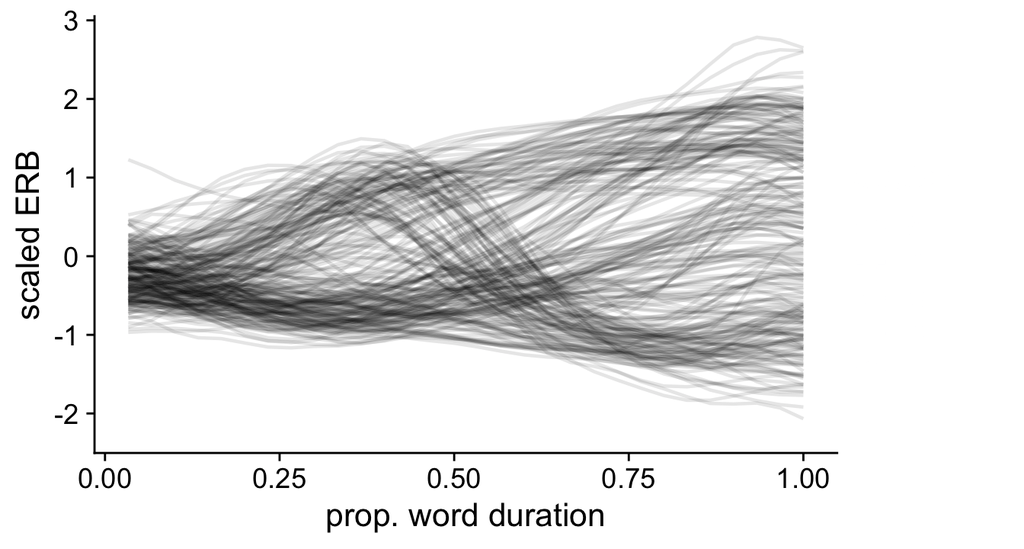

## A few first things

### This work supported by the NSF (BCS-1944773)

### Repository: https://github.com/jsteffman/k-means-clustering

- This will also eventually (…) be a tutorial on https://jsteffman.github.io/teaching.html
- For much more on this data see: Cole, J. & Steffman, J. & Shattuck-Hufnagel, S. & Tilsen, S. (2023) “Hierarchical distinctions in the production and perception of nuclear tunes in American English”, Laboratory Phonology 14(1). doi: https://doi.org/10.16995/labphon.9437
- R package for traditional k-means clustering: Charrad, M., Ghazzali, N., Boiteau, V., Niknafs, A. (2014). NbClust: An R Package for Determining the Relevant Number of Clusters in a Data Set. Journal of Statistical Software, 61(6), 1-36. URL http://www.jstatsoft.org/v61/i06/
- R package for time-series k-means clustering: Genolini, C., Alacoque, X., Sentenac, M., Arnaud, C. (2015). kml and kml3d: R Packages to Cluster Longitudinal Data. Journal of Statistical Software, 65(4), 1-34. URL http://www.jstatsoft.org/v65/i04/

## Imitative Speech production paradigm

### 30 American English speakers

### 3 model utterances heard on a trial, 2 different speakers

- “She quoted Helena”, “He answered Jeremy”, “Her name is Marilyn”
- 8 “nuclear” distinct tunes on the final word, resynthesized F0

### New, metrically similar, sentence produced

- “They honored Melanie”, “He modeled harmony”, “She remained with Madelyn”
- Instructions to imitate the melody of the utterance

### F0 measures over the final word

- Here, 30 time-scaled samples, speaker means for each of the 8 stimulus tunes (8 trajectories per speaker, 240 total)
- Converted to ERB and scaled within speaker (normalising speaker F0 level/range differences)

## Stimuli and Data

#### What 30 participants heard (left), and what they produced (right)

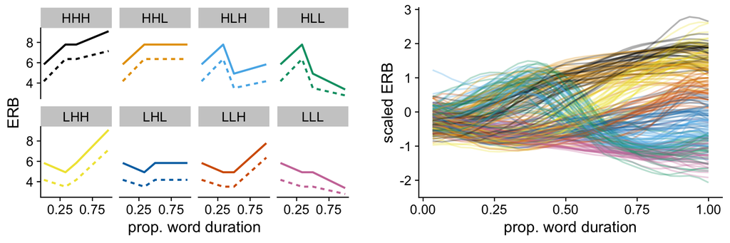

## To begin, k-means in 2D

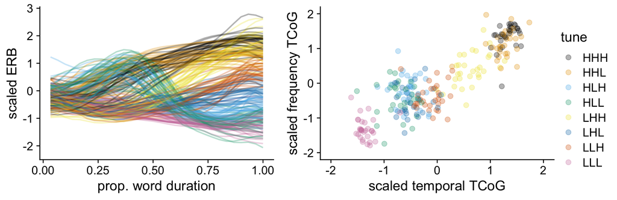

#### For llustration, trajectories made 2D, using “Tonal Center of Gravity”

- *Temporal TCoG*: Roughly, when in scaled time is F0 the highest? Earlier for falls, later for rises
- *Frequency TCoG*: Here just mean F0 (can be weighted in various ways)

## To begin, k-means in 2D

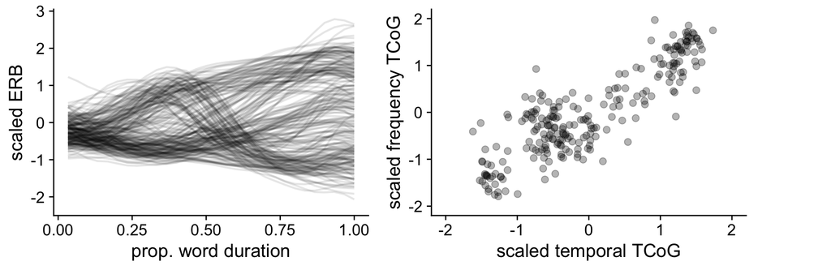

## k-means in 2D

#### Seeds are set

#### (often at random, though other methods exist)

#### Three chosen here arbitrarily: *the number of seeds will be the number of clusters*

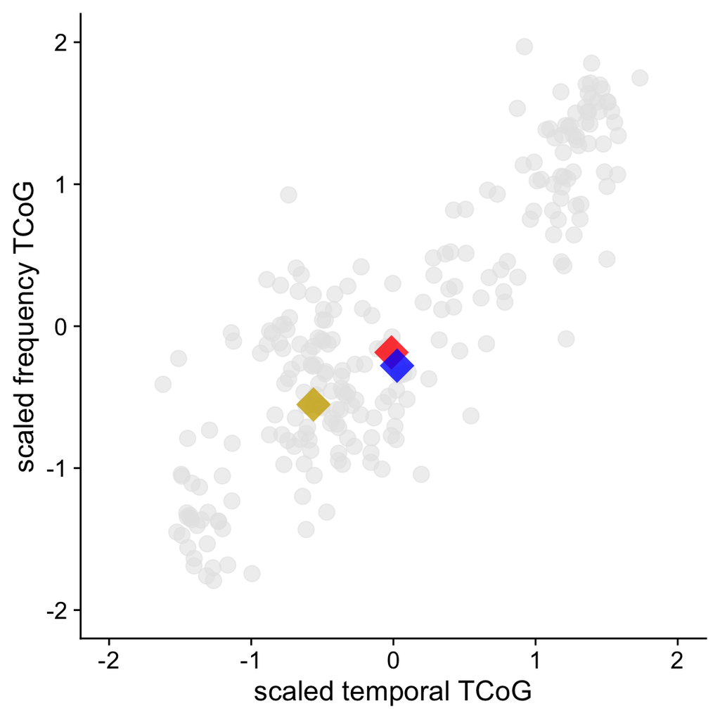

## k-means in 2D

#### Points are allocated to clusters based on proximity to seeds (often Euclidian distance)

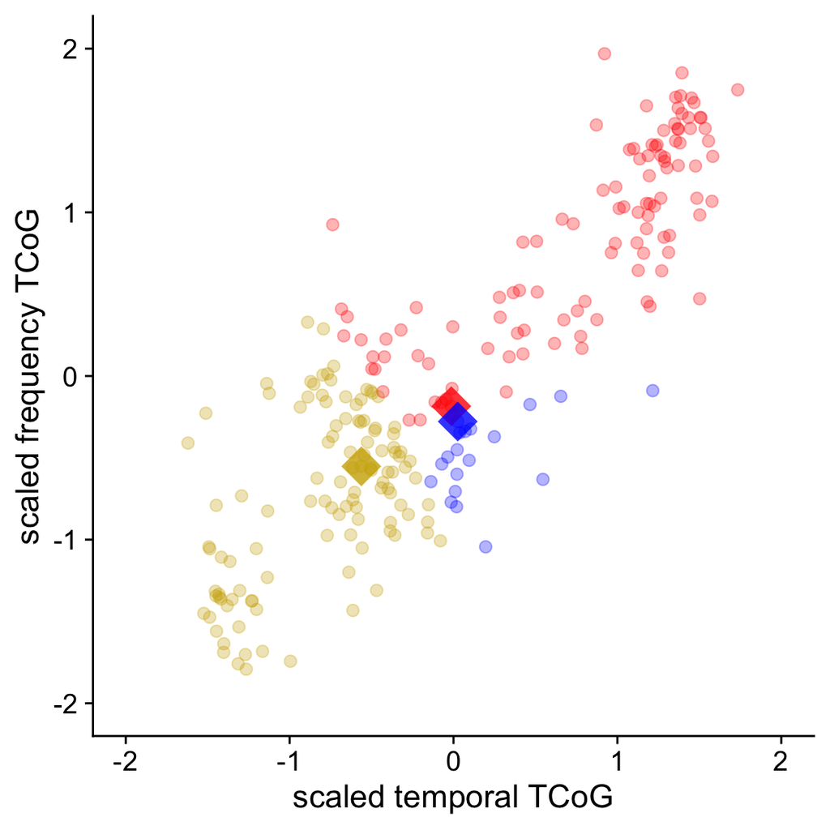

## k-means in 2D

#### Cluster centroids are derived based on this first partition

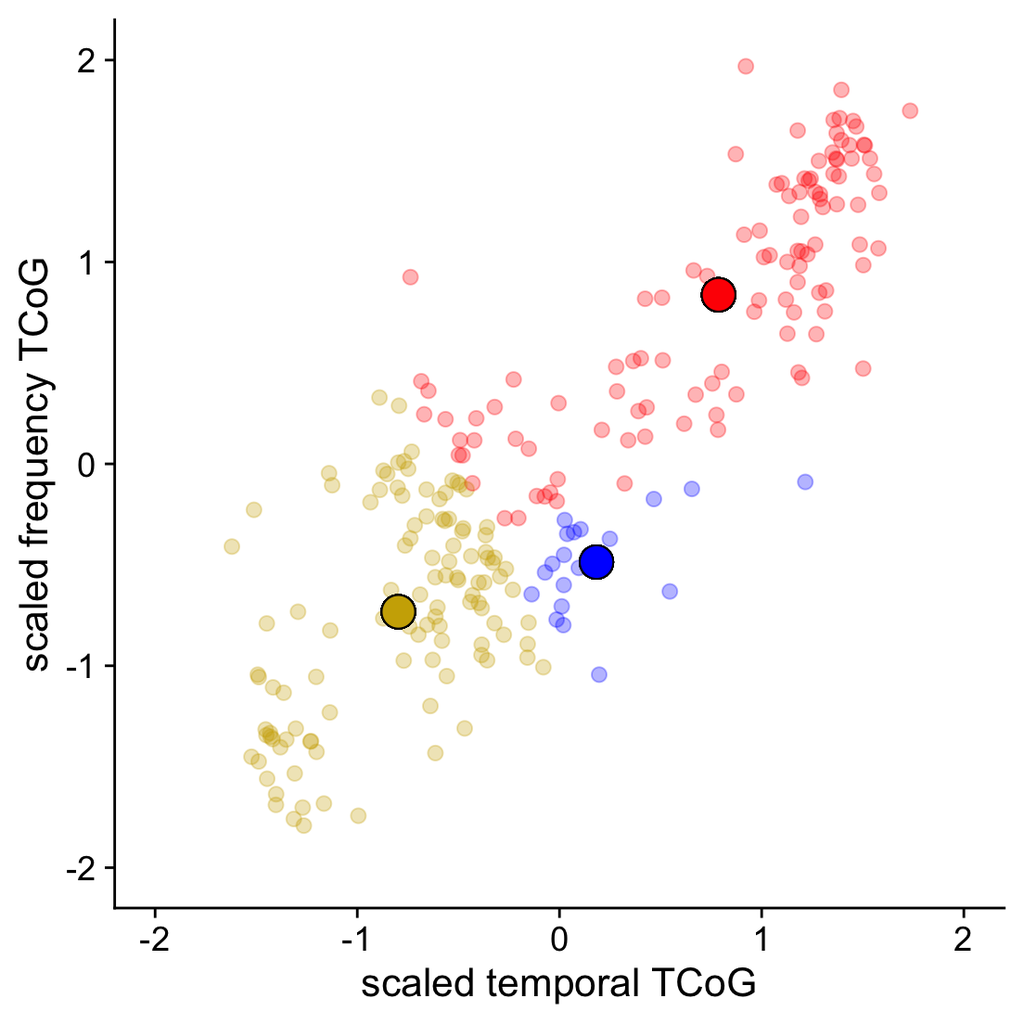

## k-means in 2D

#### Distance from the centroids is computed, and points are re-allocated

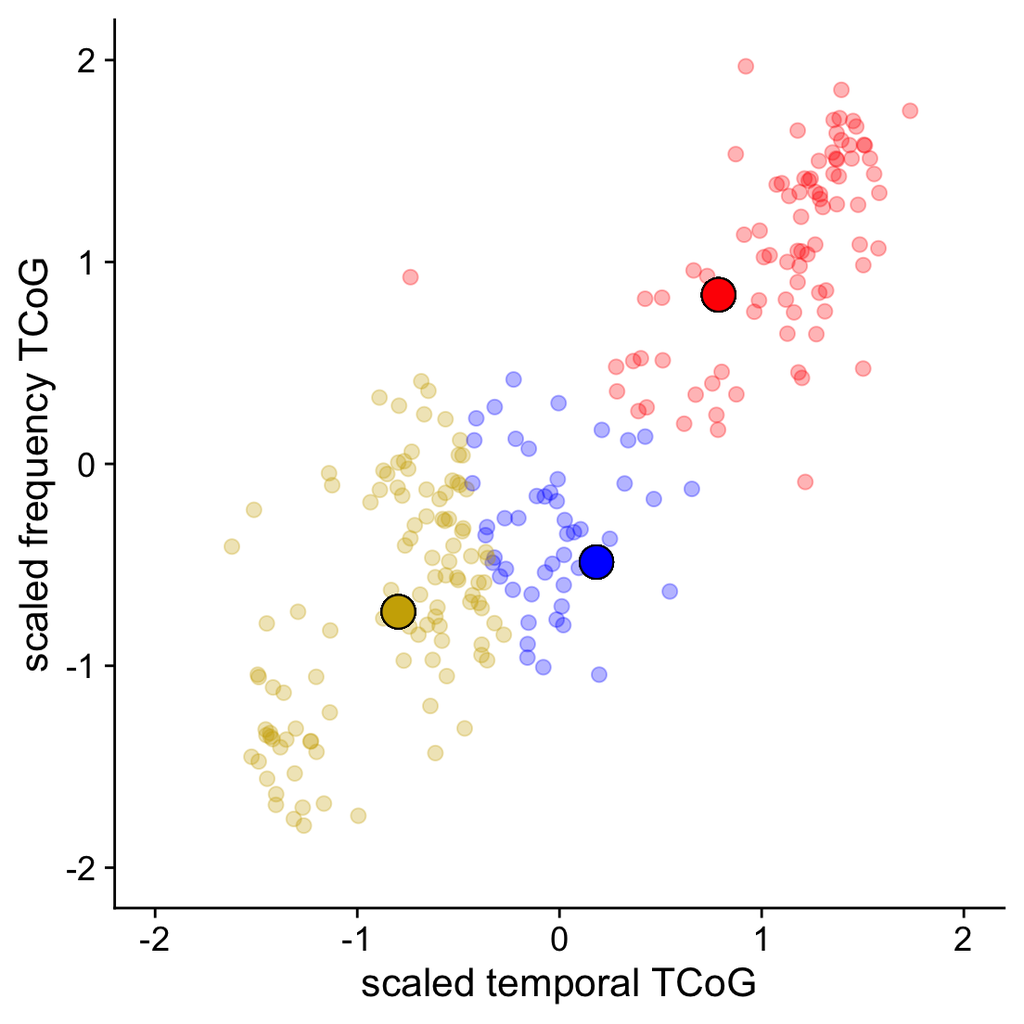

## k-means in 2D

#### New centroids are derived based on re-allocated points

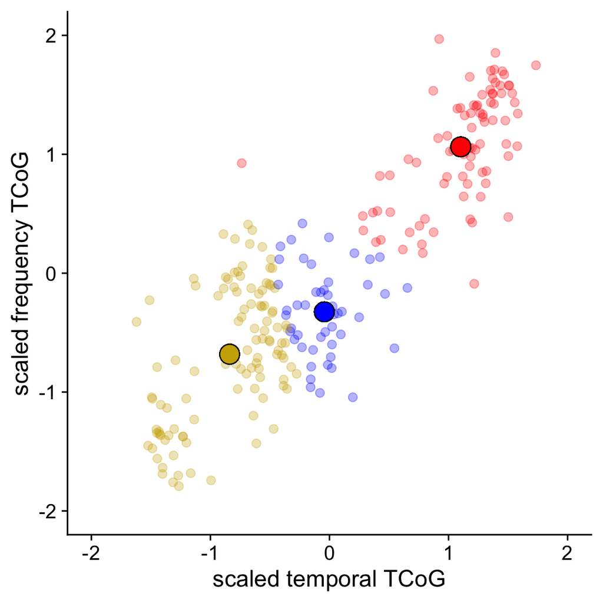

## k-means in 2D

#### And, the process repeats …

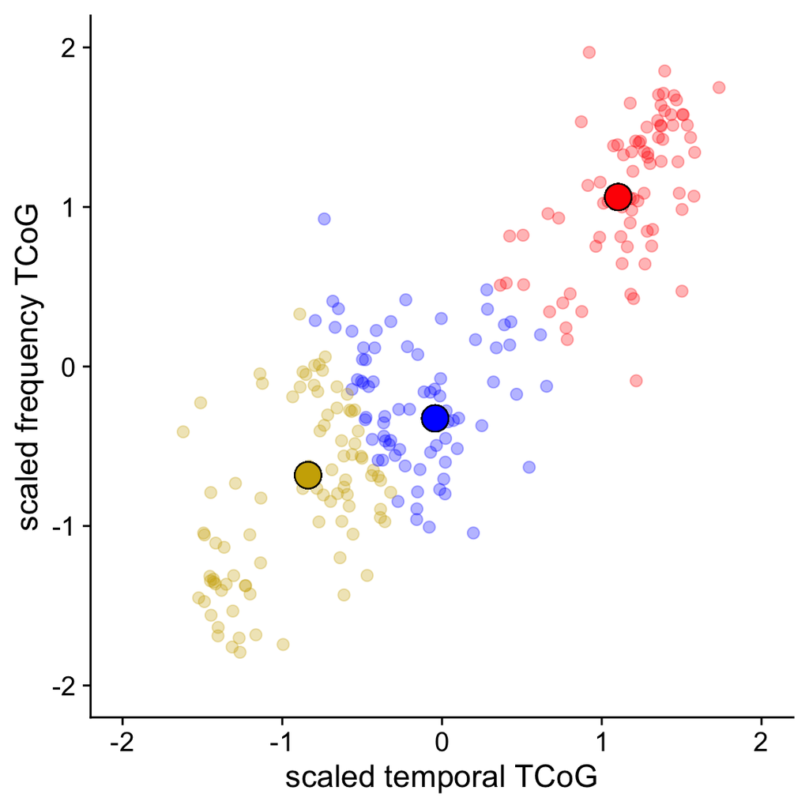

## k-means in 2D

#### And, the process repeats …

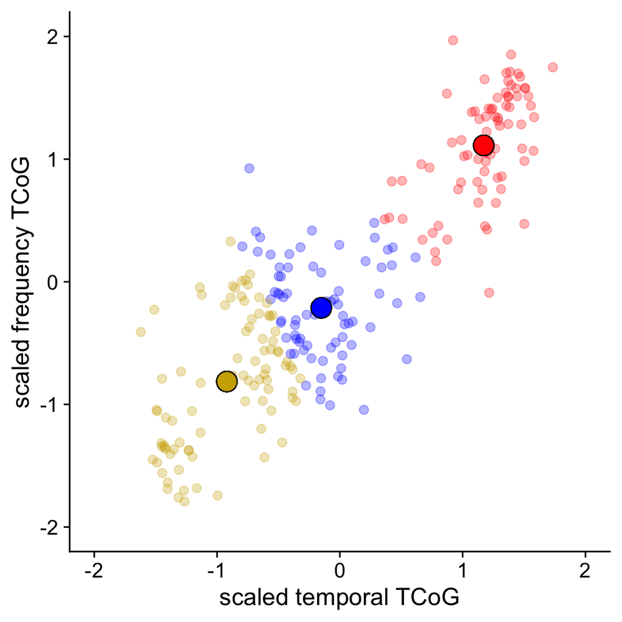

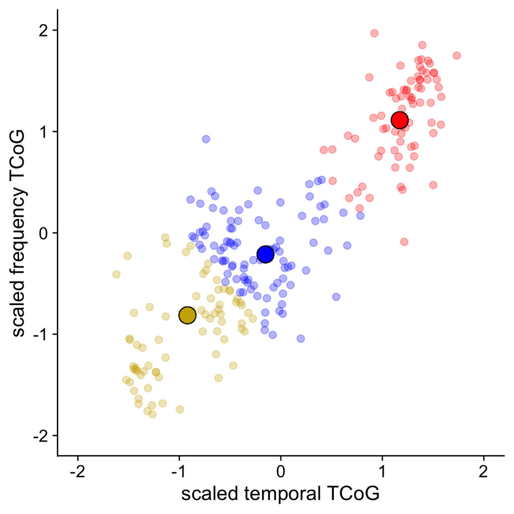

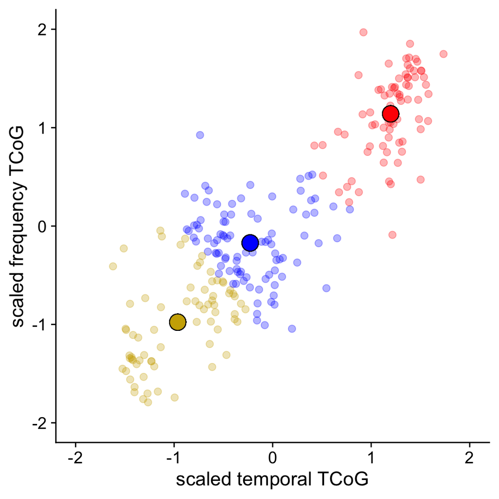

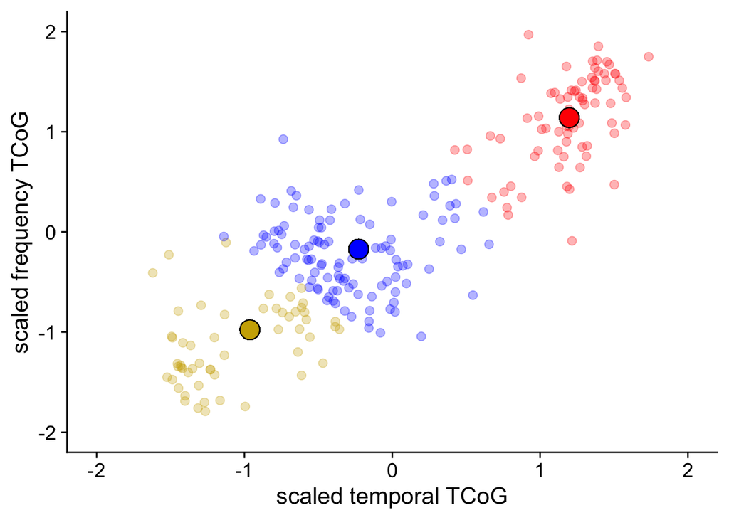

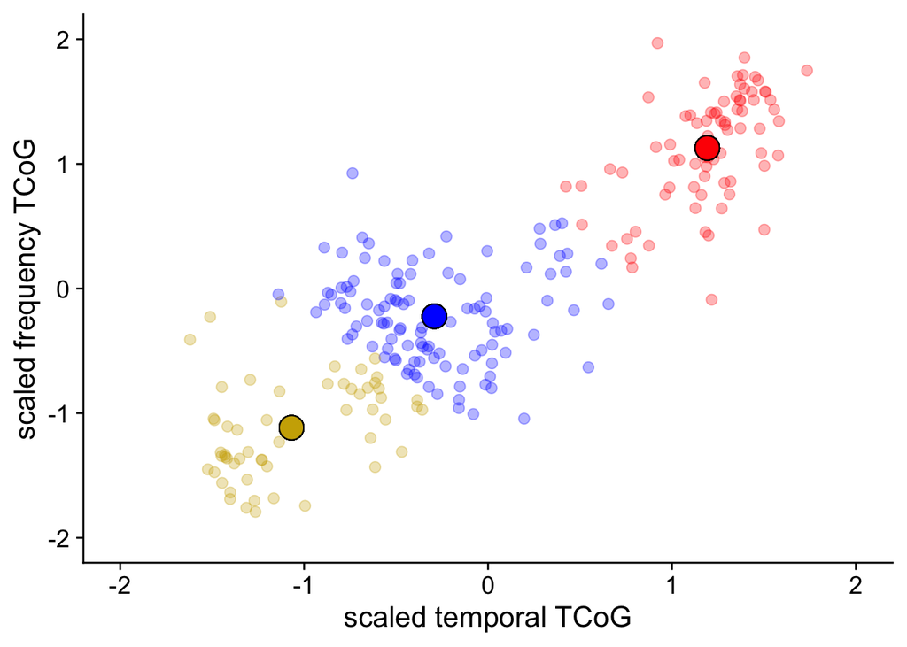

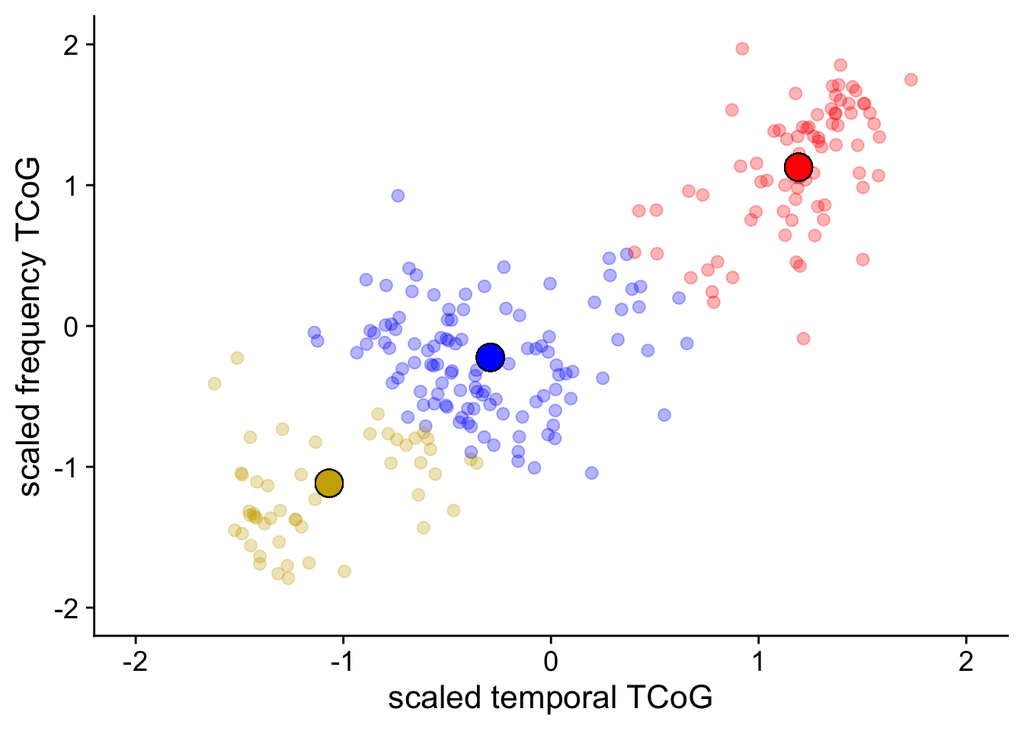

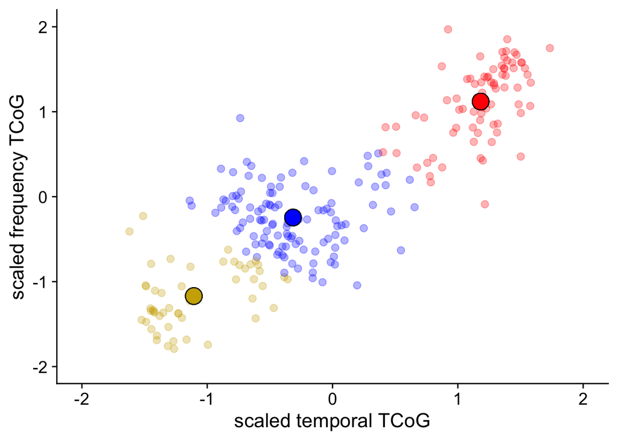

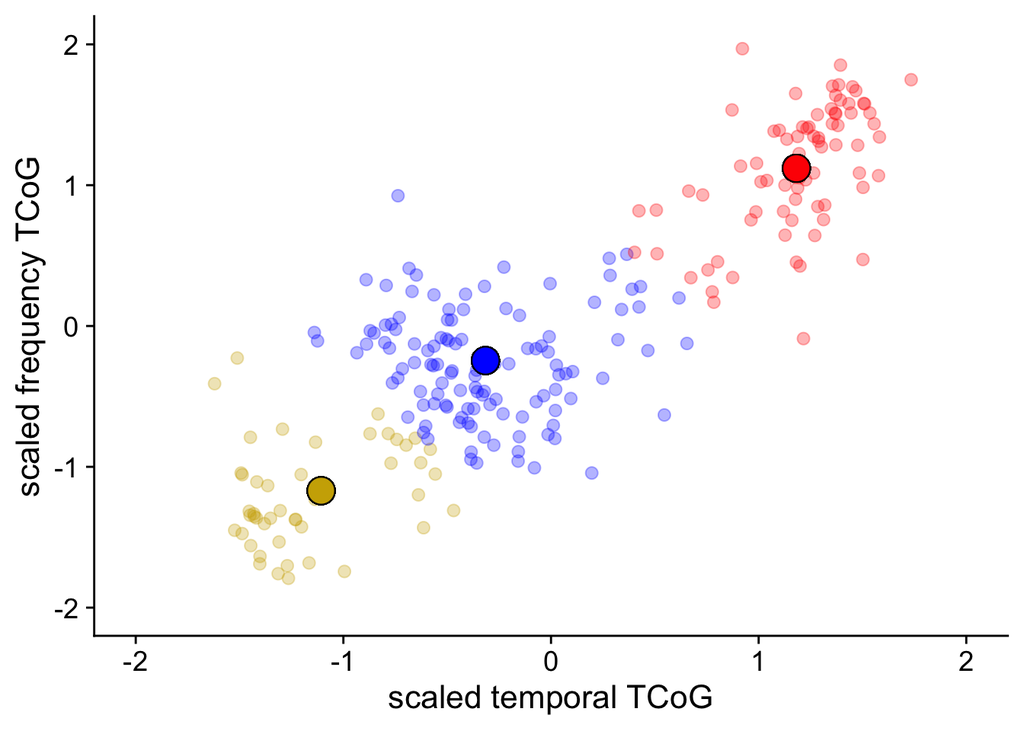

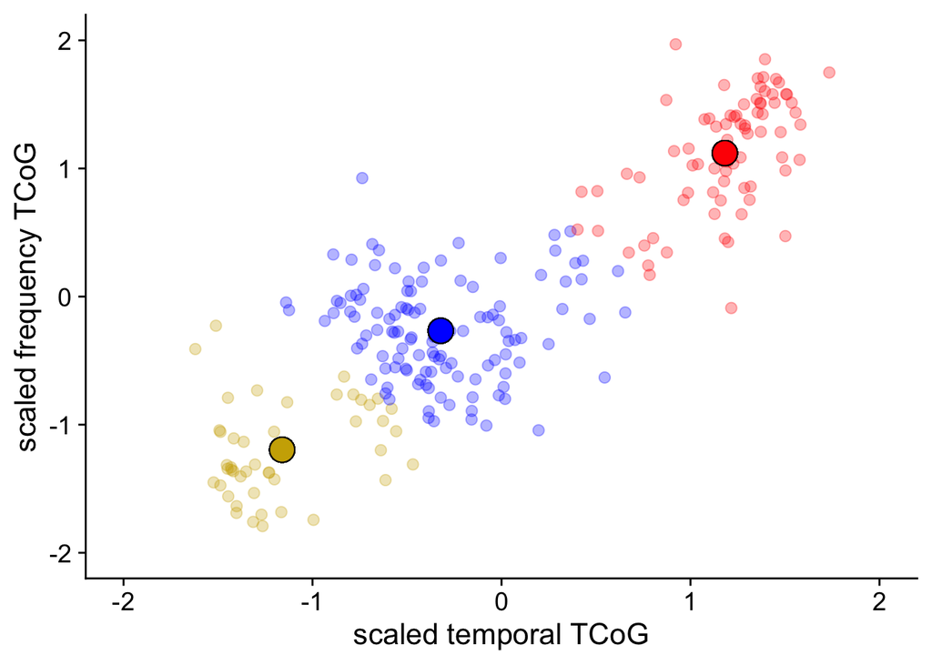

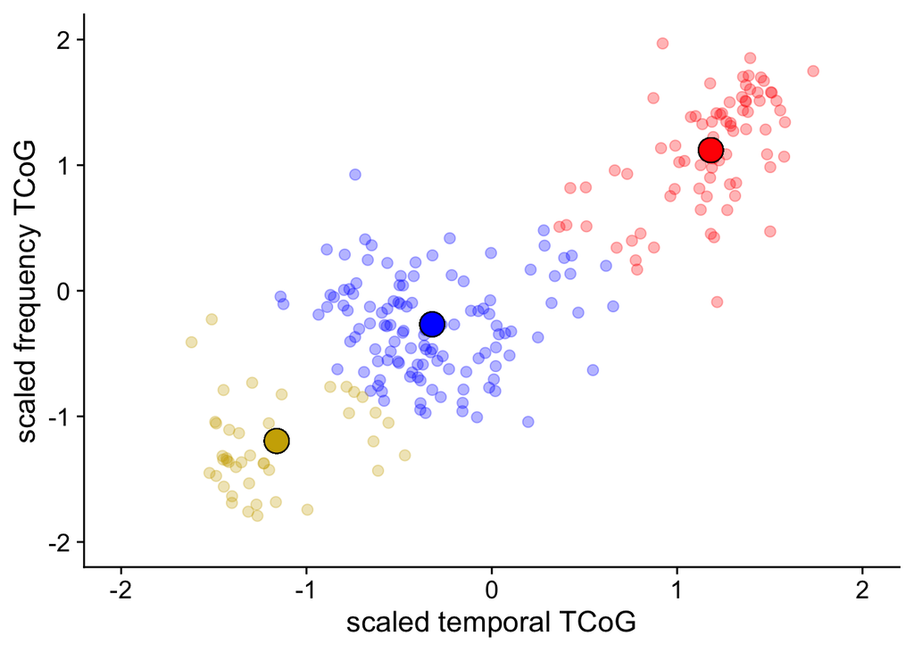

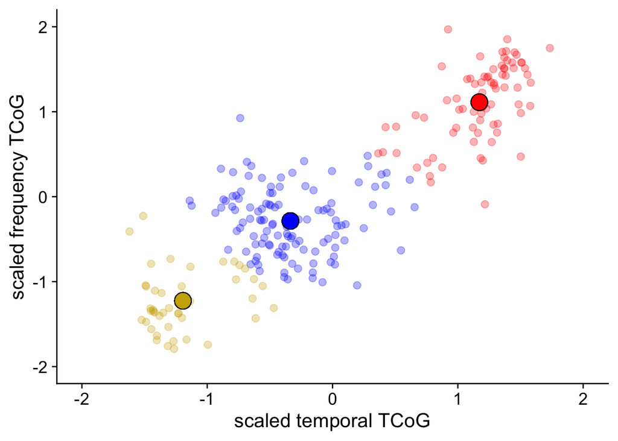

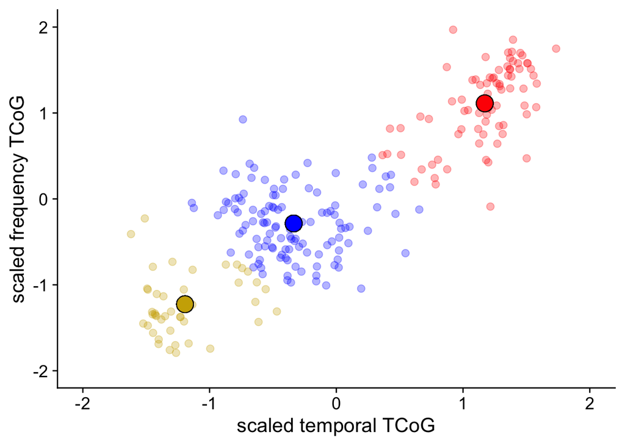

[2 more figures not shown]

## k-means in 2D

#### Until a solution is converged upon

#### No more shuffling of points

[figure not shown]

## Many ks, many possible solutions

#### Cluster solution evaluation and optimization is thus a critical part of analysis

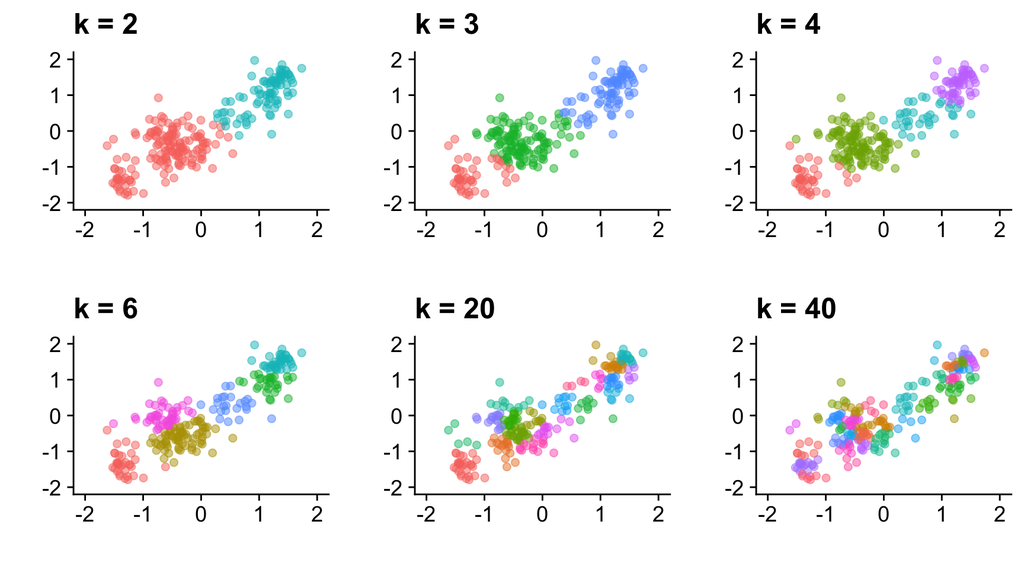

## Selecting the optimal k value

- Various criteria: General intuition is the “best” partition optimizes within and between cluster variance
- R packages allow for comparison across multiple criteria, can also evaluate by “majority vote”
- In addition to this “best” k value, others may be of interest as informed by predictions or theory

## Selecting the optimal k value

- Various criteria: General intuition is the “best” partition optimizes within and between cluster variance
- R packages allow for comparison across multiple criteria, can also evaluate by “majority vote”
- In addition to this “best” k value, others may be of interest as informed by predictions or theory

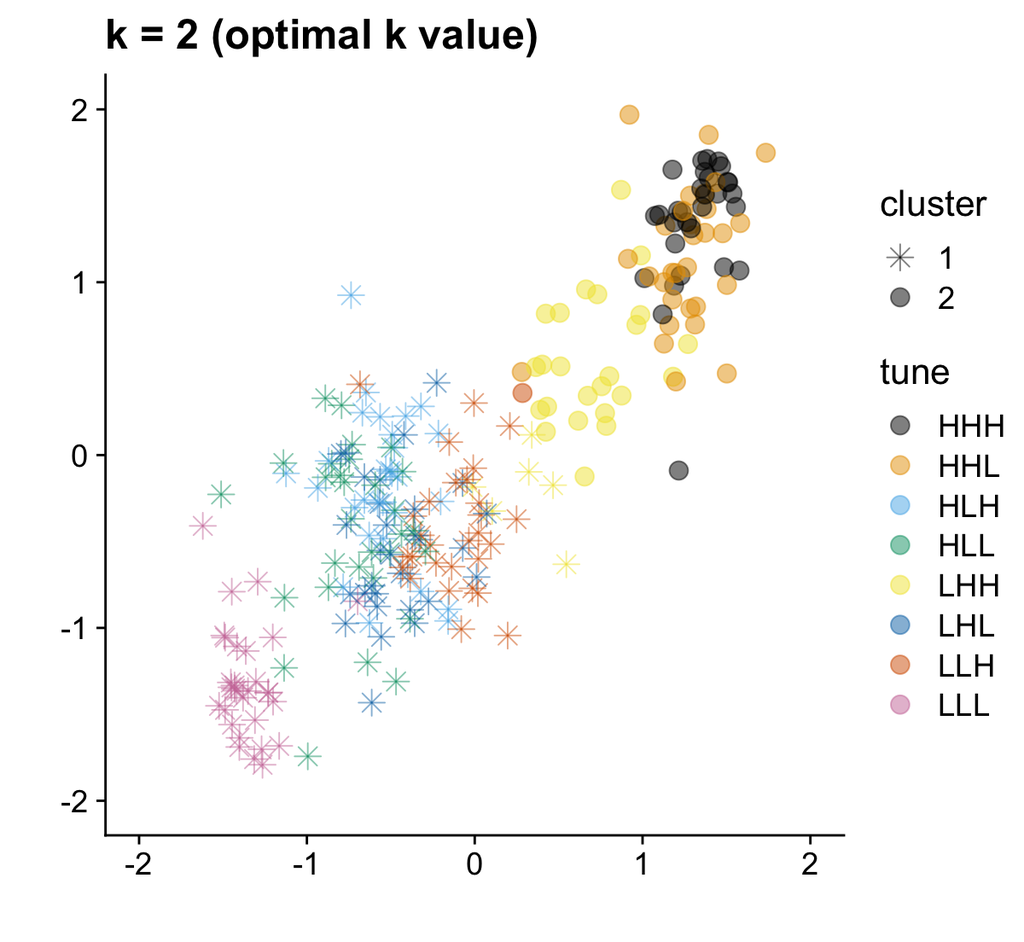

## Translating to time series

#### The key difference is in the understanding of DISTANCE, where distances are considered at each time point when comparing two trajectories

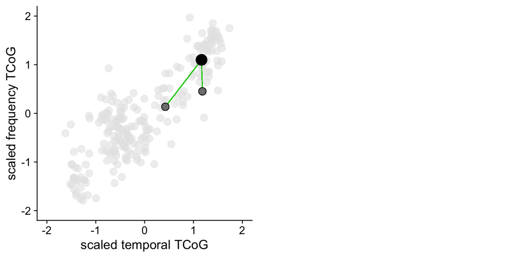

## Translating to time series

#### The key difference is in the understanding of DISTANCE, where distances are considered at each time point when comparing two trajectories

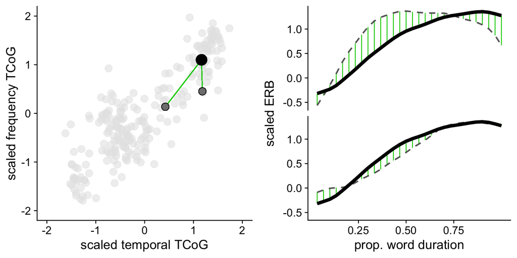

## Translating to time series

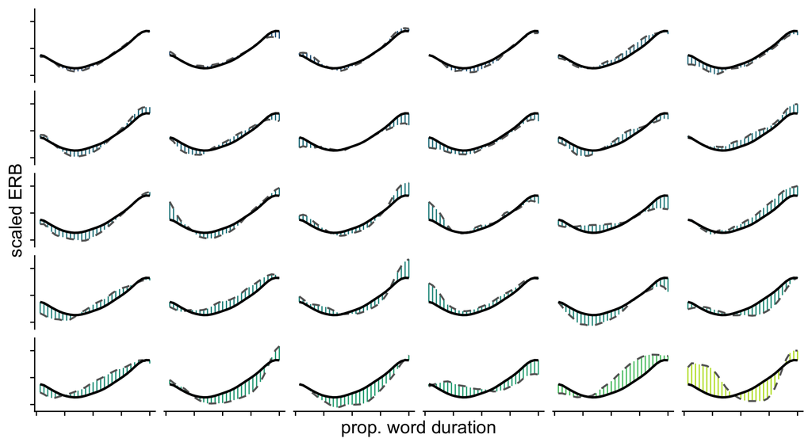

## Application to the data

#### In the data set, *five* was selected as the optimal number of clusters

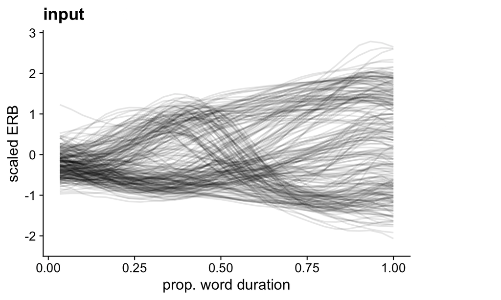